## Exercise Two: Pie Charts

### When to use a Pie Chart, when to use a bar chart and when to use both together!

The Packages required to complete this exercise have been loaded above. These include ggplot2, dplyr, We have also created a function to help you use both the bar and pie charts to efficiently display the data. As mentioned in the workshop, Pie Charts are really good if there are only 2 or 3 wedges, however if you have more wedges it is harder to visually disern exact information and to make comparisions. There are three datasets provided below, take a look the data and determine which visualisation is most appropriate.

The data below is stored as `DatasetOne` and the data is taken from https://countrymeters.info/en/Australia.

|  | Sex | Percentage |
| --- | --- | --- |
| 1 | Female | 0.498 |
| 2 | Male | 0.502 |

What do you think would be the most appropriate way to visualise this information? Fill in the missing parameters below. Don’t forget to use the ggplot2 **cheat sheet** to help you.

```r
  #ggplot(data = DatasetOne, aes(x = "", y = Percentage, fill = Sex)) + _____(stat = "identity") + ______ (_____, start=____)
```

Don’t forget to uncomment the function in order to test your answer.

**ANSWER: If you take a look at the dataset, you can note that if we used a Pie Chart there would only be two wedges. Therefore, if you plotted a pie chart you would have been correct. Note, if you plotted a bar chart that would also have been correct**

To explore, lets take a look at how easy it is to compare two countries population distributions using pie charts. The Pie Charts below compare Australia to Saudi Arabia.

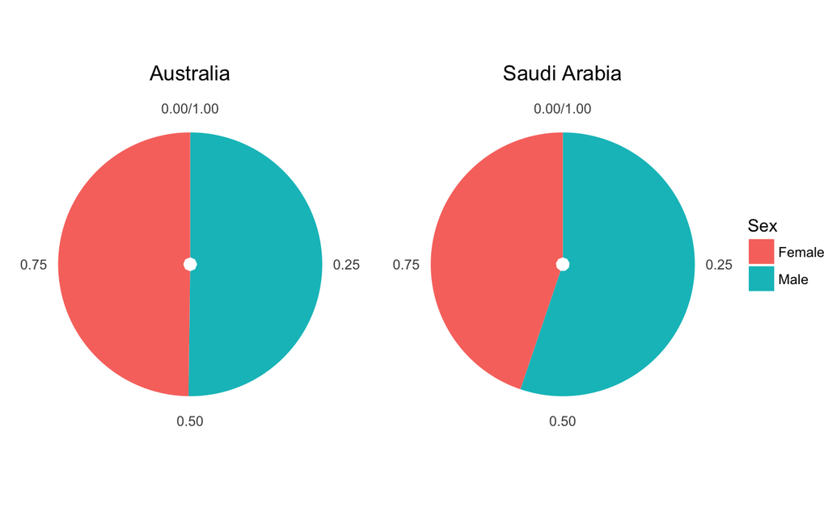

#### Now, lets take a look at the next dataset.

**Dataset Two**, stored in `DatasetTwo`, contains the proportion of the population of Australia in each 5 year age group. The data was taken from Australian Bureau of Statistics, Census of Population and Housing 2011 and 2016. Compiled and presented by .id , the population experts (https://profile.id.com.au/australia/five-year-age-groups).

| age_groups | Number | percentage | Capital_Cities |
| --- | --- | --- | --- |
| 0 to 4 | 1464776 | 6.2592 | 6.3988 |
| 5 to 9 | 1502644 | 6.4210 | 6.3838 |
| 10 to 14 | 1397182 | 5.9704 | 5.8507 |
| 15 to 19 | 1421612 | 6.0748 | 6.0917 |
| 20 to 24 | 1566792 | 6.6951 | 7.1904 |
| 25 to 29 | 1664609 | 7.1131 | 7.7763 |
| 30 to 34 | 1703852 | 7.2808 | 7.9582 |
| 35 to 39 | 1561686 | 6.6733 | 7.1384 |
| 40 to 44 | 1583254 | 6.7655 | 6.9753 |
| 45 to 49 | 1581460 | 6.7578 | 6.8002 |

[output cut: 8 more lines]

```r
#ggplot(data = DatasetTwo, aes(x = _______ , y = percentage, fill = age_groups)) + _____(position = "_____", stat = "identity") + theme(axis.text.x = element_text(angle = 90, hjust = 1))
```

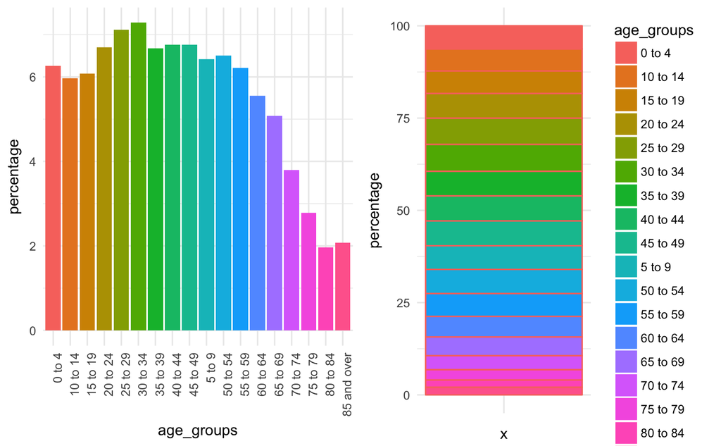

| Religion | Percentage |
| --- | --- |
| Australia | 66.70 |
| United Kingdom | 4.64 |
| New Zealand | 2.21 |
| China | 3.09 |
| India | 2.66 |
| Phillippines | 1.19 |
| Vietnam | 1.36 |
| Italy | 0.96 |
| South Africa | 0.82 |
| Malaysia | 0.82 |

[output cut: 3 more lines]